# A study of the 3 bars pattern setup, with some changes…

Andrea Nalon

16 November 2015

This document will test one of the best known pattern: the 3 bars reversal setup. If a setup is found, a BUY order is triggered. **Only long trades are covered in this study, not shorts.**

**RULES FOR LONG**  
1. Bar 1 closes down  
2. Low of Bar 2 is below low of Bar 1 (and Bar 3)  
3. High of Bar 2 is below high of Bar 1  
4. Bar 3 closes above the high of both Bar 1 and Bar 2  
5. Buy at close of Bar 3

**My suggestion is to modify the rule 4 and 5:**  
4. Place a BUY STOP order at high of Bar 2  
5. so if it was triggered, it would buy at high of Bar 2

This seems to enhance the risk/reward ratio, since the entry price is closer to the stop level.

### The asset used for the simulation is the S&P 500 index future, with daily bars.

*All the simulations include a slippage of 1 basis points for each roundturn (open - close trade).*

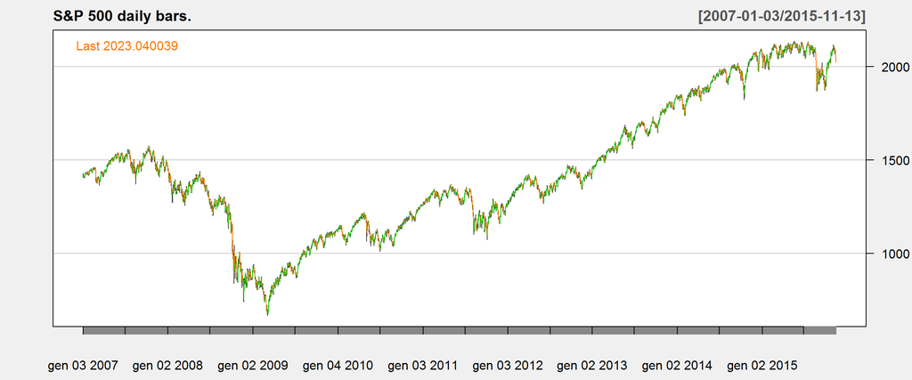

## Simulation 1.

Each trade is managed with a trailing stop set to the previous low. The slippage for each roundturn is 1 points.

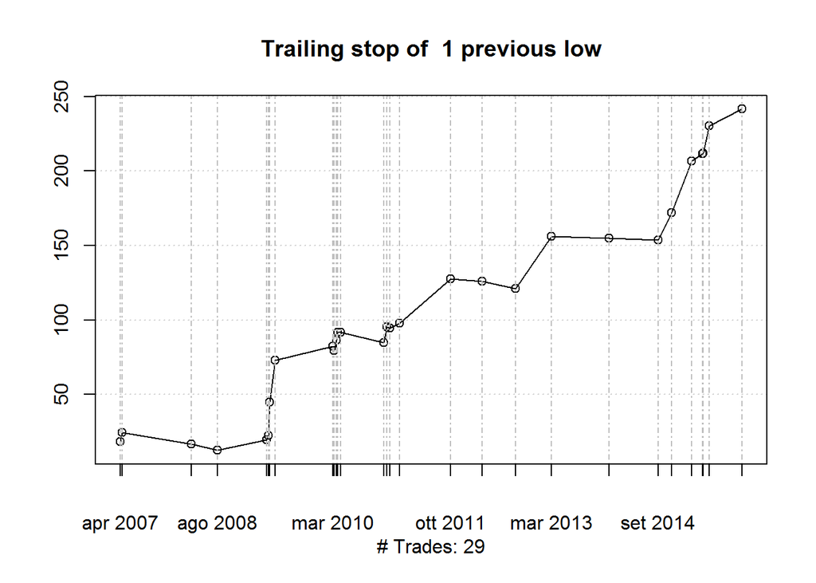

## Simulation 2.

Each trade is managed with a stop level, set upon the volatility of the last 68 bars. The slippage for each roundturn is 1 points.

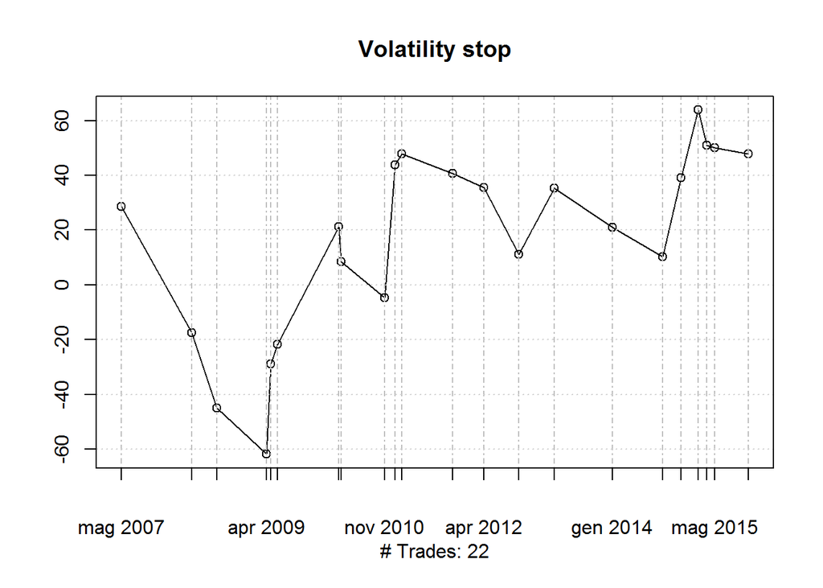

## Simulation 3.

Each trade is managed with a fixed stop level of -8 points. The slippage for each roundturn is 1 points.

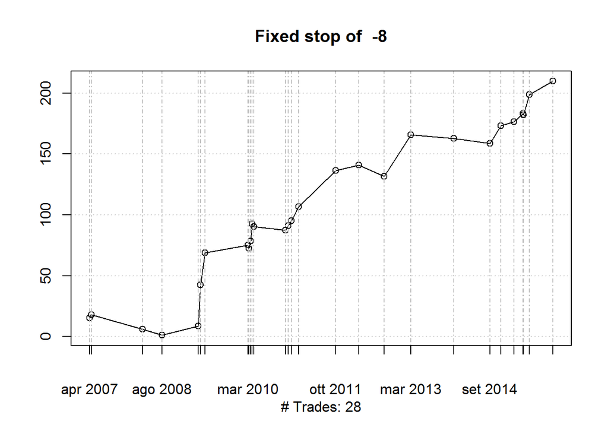